# Question

A standard six-sided [die](https://en.wikipedia.org/wiki/Dice) was rolled 50 times, and the results were organized into the [pie chart](https://en.wikipedia.org/wiki/Pie_chart) shown below. The marks outside of the circle indicate the cumulative proportion.

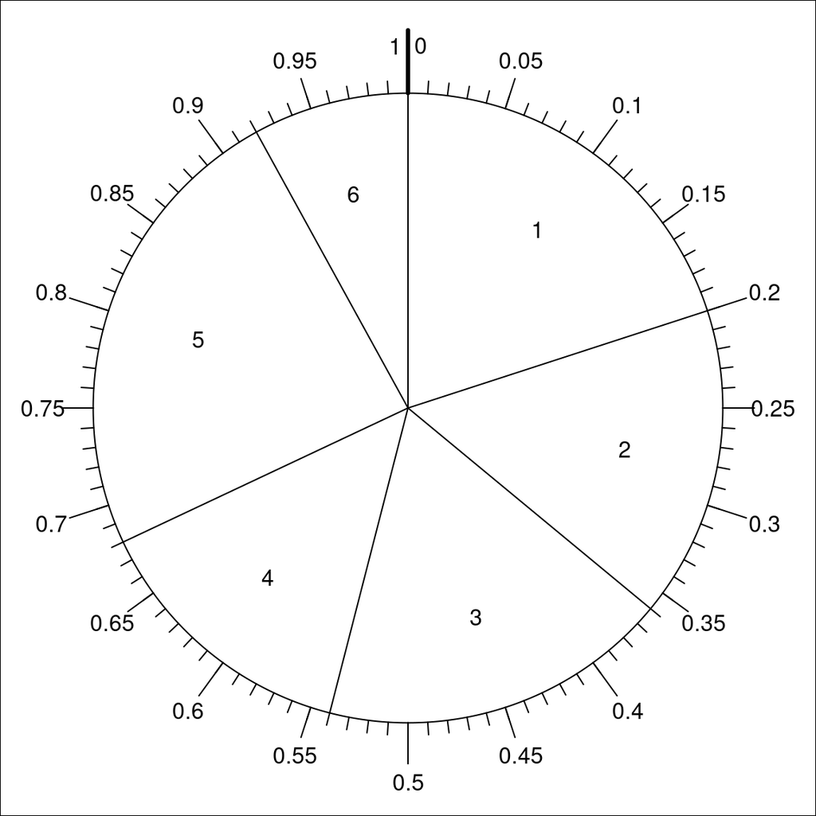

## Answerlist

- Evaluate $\text{prop}[\mathbf{x}<4.5]$.
- Evaluate $\text{prop}[\mathbf{x}>3.5]$.
- Evaluate $\text{prop}[|\mathbf{x}-2|<0.5]$.
- Evaluate $\text{prop}[|\mathbf{x}-3|>1.5]$.
- Evaluate half-integer boundary $b$ such that $\text{prop}[\mathbf{x}<b] = 0.92$.
- Evaluate half-integer boundary $b$ such that $\text{prop}[\mathbf{x}>b] = 0.46$.
- Evaluate integer radius $r$ such that $\text{prop}[|\mathbf{x}-3.5|<r] = 0.32$.
- Evaluate half-integer radius $r$ such that $\text{prop}[|\mathbf{x}-4|>r] = 0.44$.

# Solution

The first 4 questions involve adding up relative frequencies of the indicated intervals. The last 4 questions can be done by guessing and checking until something works.

## Answerlist

- The proportion of measurements less than 4.5 is 0.68.
  $$\text{prop}[\mathbf{x}<4.5]=0.68$$
- The proportion of measurements more than 3.5 is 0.46.
  $$\text{prop}[\mathbf{x}>3.5]=0.46$$
- The proportion of measurements closer than 0.5 units from 2 is 0.16.
  $$\text{prop}[|\mathbf{x}-2|<0.5]=0.16$$
- The proportion of measurements farther than 1.5 units from 3 is 0.52.
  $$\text{prop}[|\mathbf{x}-3|>1.5]=0.52$$
- The proportion of measurements less than 5.5 is 0.92.
  $$\text{prop}[\mathbf{x}<5.5]=0.92$$
- The proportion of measurements more than 3.5 is 0.46.
  $$\text{prop}[\mathbf{x}>3.5]=0.46$$
- The proportion of measurements closer than 1 units from 3.5 is 0.32.
  $$\text{prop}[|\mathbf{x}-3.5|<1]=0.32$$
- The proportion of measurements farther than 1.5 units from 4 is 0.44.
  $$\text{prop}[|\mathbf{x}-4|>1.5]=0.44$$

# Meta-information

extype: cloze exclozetype: num|num|num|num|num|num|num|num exsolution: 0.68|0.46|0.16|0.52|5.5|3.5|1|1.5 exname: read_circle_prop extol: 0 exextra[numwidth,character]: 999.99